# Getting started with neural networks

MACS 30200 University of Chicago

## Layers

- Layer
- Stateless layer
- Stochastic gradient descent
- Knowledge

## Layers for different tensors

- Densely connected layers - 2D tensor
- Recurrent layers - 3D tensor
- 2D convolution layers - 4D tensor

## Connecting layers

- Each layer is connected to one another
- Output of layer becomes input of next layer
- Need to make sure each layer accepts the output from previous layer

## Models

- Directed, acyclic graph of layers
  - Graph
  - Directed
  - Acyclic
- Linear stack of layers
- Hypothesis space
- No clear guidelines for defining network architecture

## Loss functions and optimizers

- Loss function
- Optimizer
- Neural networks can have multiple outputs with multiple loss functions

## Loss function

- Needs to be appropriate for the data and task at hand
- Inappropriate loss functions lead to bad models
- Binary classification - binary crossentropy
- Multi-class classification - categorical crossentropy
- Regression - mean-squared error

## Keras

- Deep-learning framework that provides a convenient way to define and train almost any kind of deep learning model
- Runs on CPU or GPU
- Easy to work with API
- Works with many kinds of networks

## Keras, TensorFlow, Theano, and CNTK

- Keras is a model-level library
- Does not do the low-level tensor operations itself
- Tensor library
  - TensorFlow
  - Theano
  - Microsoft Cognitive Toolkit (CNTK)

## Typical workflow

1. Define your training data
2. Define a network of layers that maps inputs to your targets
3. Configure the learning process by choosing a loss function, an optimizer, and some metrics to monitor
4. Iterate on your training data

## Setting up a deep-learning workstation

- Have a powerful GPU (typically NVIDIA)
- CPU processing is for chumps
- Can be run on the cloud via AWS or Google Cloud

## Binary classification: IMDB dataset

- Set of 50,000 highly-polarized reviews from IMDB
- 25,000 for training
- 25,000 for testing
- Each has 50% negative and 50% positive reviews

## Import data

```r
library(keras)
imdb <- dataset_imdb(num_words = 10000)
c(c(train_data, train_labels), c(test_data, test_labels)) %<-% imdb
```

```r
str(train_data[[1]])
```

```
##  int [1:218] 1 14 22 16 43 530 973 1622 1385 65 ...
```

```r
train_labels[[1]]
```

```
## [1] 1
```

## One-hot-encoding

```r
vectorize_sequences <- function(sequences, dimension = 10000) {
  # Create an all-zero matrix of shape (len(sequences), dimension)
  results <- matrix(0, nrow = length(sequences), ncol = dimension)
  for (i in 1:length(sequences))
    # Sets specific indices of results[i] to 1s
    results[i, sequences[[i]]] <- 1
  results
}

# Our vectorized training data
x_train <- vectorize_sequences(train_data)
# Our vectorized test data
x_test <- vectorize_sequences(test_data)
```

```r
str(x_train[1,])
```

```
##  num [1:10000] 1 1 0 1 1 1 1 1 1 0 ...
```

```r
# Our vectorized labels
y_train <- as.numeric(train_labels)
y_test <- as.numeric(test_labels)
```

## Building our network

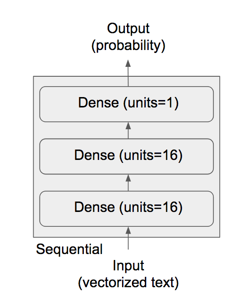

## Building our network

```r
library(keras)

model <- keras_model_sequential() %>%
  layer_dense(units = 16, activation = "relu", input_shape = c(10000)) %>%
  layer_dense(units = 16, activation = "relu") %>%
  layer_dense(units = 1, activation = "sigmoid")
```

## Compiling the network

```r
model %>% compile(
  optimizer = "rmsprop",
  loss = "binary_crossentropy",
  metrics = c("accuracy")
)
```

- Binary crossentropy
- `rmsprop` optimizer
- Monitor accuracy during training

## Validating our approach

```r
val_indices <- 1:10000

x_val <- x_train[val_indices,]
partial_x_train <- x_train[-val_indices,]

y_val <- y_train[val_indices]
partial_y_train <- y_train[-val_indices]
```

## Fit the model

```r
model %>% compile(
  optimizer = "rmsprop",
  loss = "binary_crossentropy",
  metrics = c("accuracy")
)

history <- model %>%
  fit(
    partial_x_train,
    partial_y_train,
    epochs = 20,
    batch_size = 512,
    validation_data = list(x_val, y_val)
  )
```

## Evaluate the model

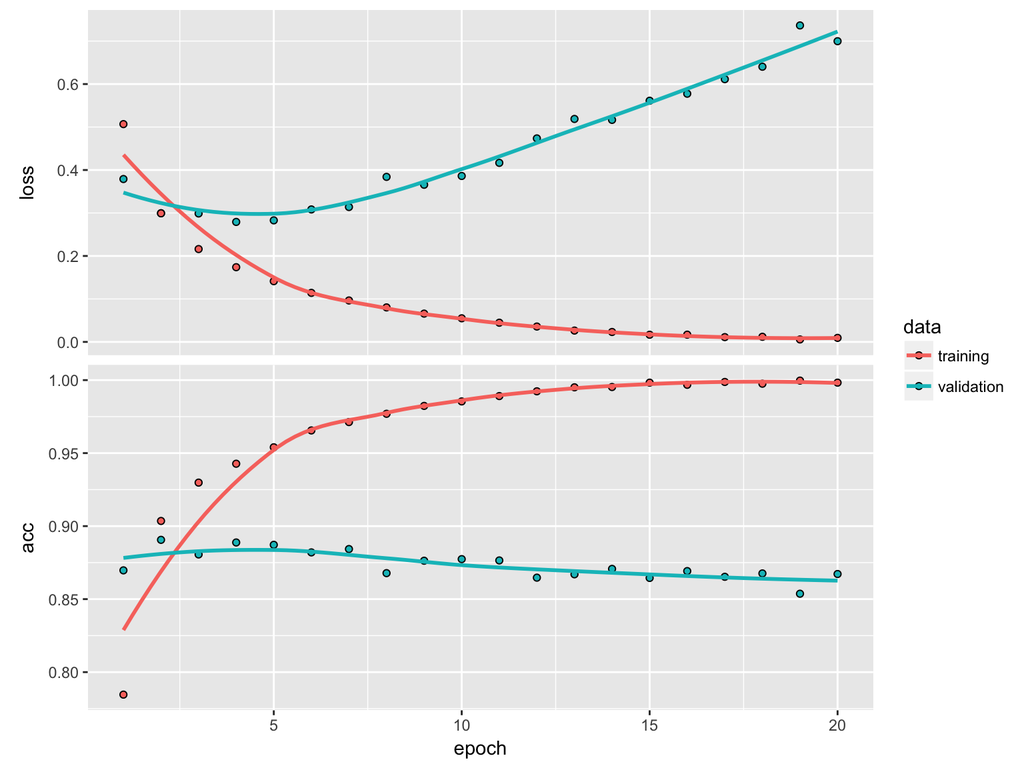

```r
plot(history)
```

## Train a new network

```r
model <- keras_model_sequential() %>%
  layer_dense(units = 16, activation = "relu", input_shape = c(10000)) %>%
  layer_dense(units = 16, activation = "relu") %>%
  layer_dense(units = 1, activation = "sigmoid")

model %>% compile(
  optimizer = "rmsprop",
  loss = "binary_crossentropy",
  metrics = c("accuracy")
)

model %>% fit(x_train, y_train, epochs = 4, batch_size = 512)
results <- model %>%
  evaluate(x_test, y_test)
```

```r
results
```

```
## $loss
## [1] 0.3062706
##
## $acc
## [1] 0.87776
```

## Conclusions

- Data usually requires preprocessing to encode it as a tensor
- Stacks of dense layers with `relu` activations solve a wide range of problems - you’ll use them frequently
- Always end binary classification with a dense layer with one unit and `sigmoid` activation
- Use binary crossentropy with binary classification
- `rmsprop` optimizer is usually a good starting place
- Avoid overfitting

## Multiclass classification: Reuters newswire

- Reuters newswires from 46 mutually-exclusive topics published in 1986
- Multiple outcomes - multi-class classification
- Single label - single-label, multi-class classification

## Import the data

```r
# clear previous models
k_clear_session()

reuters <- dataset_reuters(num_words = 10000)
c(c(train_data, train_labels), c(test_data, test_labels)) %<-% reuters
```

```r
length(train_data)
```

```
## [1] 8982
```

```r
length(test_data)
```

```
## [1] 2246
```

```r
train_data[[1]]
```

```
##  [1]    1    2    2    8   43   10  447    5   25  207  270    5 3095  111
## [15]   16  369  186   90   67    7   89    5   19  102    6   19  124   15
## [29]   90   67   84   22  482   26    7   48    4   49    8  864   39  209
## [43]  154    6  151    6   83   11   15   22  155   11   15    7   48    9
## [57] 4579 1005  504    6  258    6  272   11   15   22  134   44   11   15
## [71]   16    8  197 1245   90   67   52   29  209   30   32  132    6  109
## [85]   15   17   12
```

## Preparing the data

```r
vectorize_sequences <- function(sequences, dimension = 10000) {
  results <- matrix(0, nrow = length(sequences), ncol = dimension)
  for (i in 1:length(sequences))
    results[i, sequences[[i]]] <- 1
  results
}

x_train <- vectorize_sequences(train_data)
x_test <- vectorize_sequences(test_data)

one_hot_train_labels <- to_categorical(train_labels)
one_hot_test_labels <- to_categorical(test_labels)
```

## Building our network

```r
model <- keras_model_sequential() %>%
  layer_dense(units = 64, activation = "relu", input_shape = c(10000)) %>%
  layer_dense(units = 64, activation = "relu") %>%
  layer_dense(units = 46, activation = "softmax")
```

## Compile the network

```r
model %>% compile(
  optimizer = "rmsprop",
  loss = "categorical_crossentropy",
  metrics = c("accuracy")
)
```

## Validating our approach

```r
val_indices <- 1:1000

x_val <- x_train[val_indices,]
partial_x_train <- x_train[-val_indices,]

y_val <- one_hot_train_labels[val_indices,]
partial_y_train = one_hot_train_labels[-val_indices,]
```

## Fit the model

```r
history <- model %>% fit(
  partial_x_train,
  partial_y_train,
  epochs = 20,
  batch_size = 512,
  validation_data = list(x_val, y_val)
)
```

## Fit the model

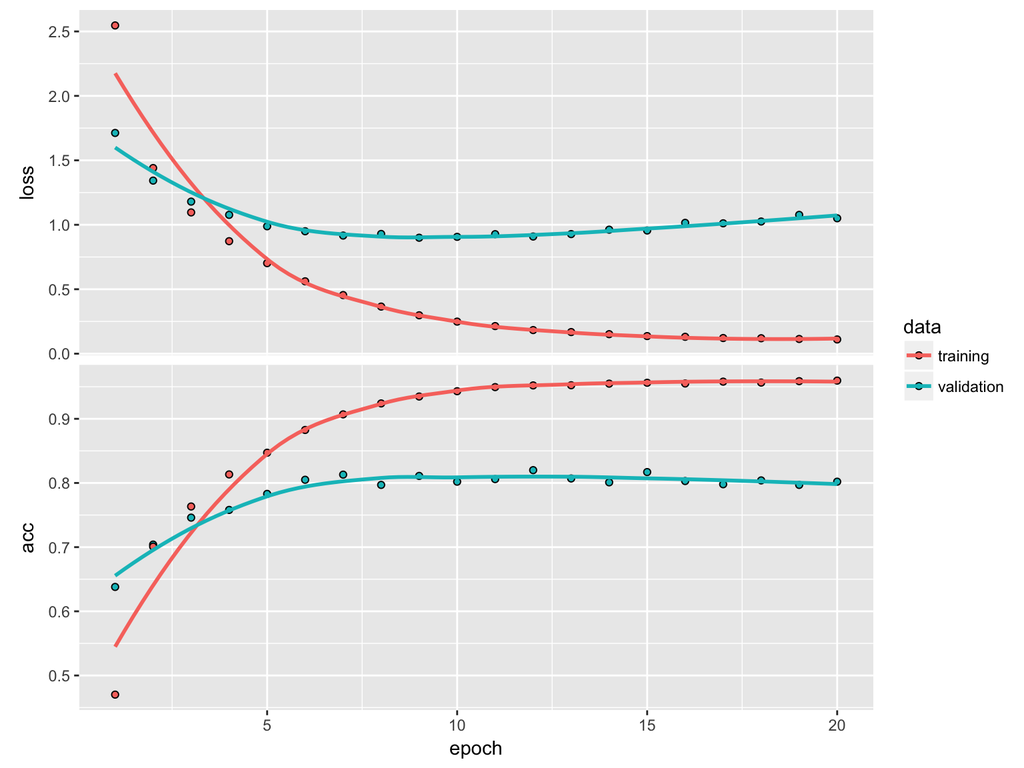

```r
plot(history)
```

## Train a new model

```r
model <- keras_model_sequential() %>%
  layer_dense(units = 64, activation = "relu", input_shape = c(10000)) %>%
  layer_dense(units = 64, activation = "relu") %>%
  layer_dense(units = 46, activation = "softmax")

model %>% compile(
  optimizer = "rmsprop",
  loss = "categorical_crossentropy",
  metrics = c("accuracy")
)

history <- model %>% fit(
  partial_x_train,
  partial_y_train,
  epochs = 9,
  batch_size = 512,
  validation_data = list(x_val, y_val)
)

results <- model %>% evaluate(x_test, one_hot_test_labels)
```

```r
results
```

```
## $loss
## [1] 1.017737
##
## $acc
## [1] 0.777382
```

## Baseline accuracy

```r
test_labels_copy <- test_labels
test_labels_copy <- sample(test_labels_copy)
length(which(test_labels == test_labels_copy)) / length(test_labels)
```

```
## [1] 0.1852182
```

## Information bottleneck

```r
model <- keras_model_sequential() %>%
  layer_dense(units = 64, activation = "relu", input_shape = c(10000)) %>%
  layer_dense(units = 4, activation = "relu") %>%
  layer_dense(units = 46, activation = "softmax")

model %>% compile(
  optimizer = "rmsprop",
  loss = "categorical_crossentropy",
  metrics = c("accuracy")
)

model %>% fit(
  partial_x_train,
  partial_y_train,
  epochs = 20,
  batch_size = 128,
  validation_data = list(x_val, y_val)
)
```

## Conclusions

- `N` classes - end with dense layer of size `N`
- Single-label, multi-class classification problem - end with `softmax` activation
- Use categorical crossentropy
- Avoid information bottlenecks

## Scalar regression: Boston housing data

```r
# clear previous sessions
k_clear_session()

dataset <- dataset_boston_housing()
c(c(train_data, train_targets), c(test_data, test_targets)) %<-% dataset
```

```r
str(train_data)
```

```
##  num [1:404, 1:13] 1.2325 0.0218 4.8982 0.0396 3.6931 ...
```

```r
str(test_data)
```

```
##  num [1:102, 1:13] 18.0846 0.1233 0.055 1.2735 0.0715 ...
```

```r
str(train_targets)
```

```
##  num [1:404(1d)] 15.2 42.3 50 21.1 17.7 18.5 11.3 15.6 15.6 14.4 ...
```

## Preparing the data

```r
mean <- apply(train_data, 2, mean)
std <- apply(train_data, 2, sd)
train_data <- scale(train_data, center = mean, scale = std)
test_data <- scale(test_data, center = mean, scale = std)
```

## Building our network

```r
# Because we will need to instantiate the same model multiple times,
# we use a function to construct it.
build_model <- function() {
  model <- keras_model_sequential() %>%
    layer_dense(units = 64, activation = "relu",
                input_shape = dim(train_data)[[2]]) %>%
    layer_dense(units = 64, activation = "relu") %>%
    layer_dense(units = 1)

  model %>% compile(
    optimizer = "rmsprop",
    loss = "mse",
    metrics = c("mae")
  )
}
```

## K-fold validation

```r
k <- 4
indices <- sample(1:nrow(train_data))
folds <- cut(1:length(indices), breaks = k, labels = FALSE)

num_epochs <- 100
all_scores <- c()
for (i in 1:k) {
  cat("processing fold #", i, "\n")
  # Prepare the validation data: data from partition # k
  val_indices <- which(folds == i, arr.ind = TRUE)
  val_data <- train_data[val_indices,]
  val_targets <- train_targets[val_indices]

  # Prepare the training data: data from all other partitions
  partial_train_data <- train_data[-val_indices,]
  partial_train_targets <- train_targets[-val_indices]

  # Build the Keras model (already compiled)
  model <- build_model()

  # Train the model (in silent mode, verbose=0)
  model %>% fit(partial_train_data, partial_train_targets,
                epochs = num_epochs, batch_size = 1, verbose = 0)

  # Evaluate the model on the validation data
  results <- model %>% evaluate(val_data, val_targets, verbose = 0)
  all_scores <- c(all_scores, results$mean_absolute_error)
}
```

```r
all_scores
```

```
## [1] 2.071110 2.196273 2.955015 2.320210
```

```r
mean(all_scores)
```

```
## [1] 2.385652
```

## K-fold validation with more epochs

```r
# Some memory clean-up
k_clear_session()
```

```r
num_epochs <- 500
all_mae_histories <- NULL
for (i in 1:k) {
  cat("processing fold #", i, "\n")

  # Prepare the validation data: data from partition # k
  val_indices <- which(folds == i, arr.ind = TRUE)
  val_data <- train_data[val_indices,]
  val_targets <- train_targets[val_indices]

  # Prepare the training data: data from all other partitions
  partial_train_data <- train_data[-val_indices,]
  partial_train_targets <- train_targets[-val_indices]

  # Build the Keras model (already compiled)
  model <- build_model()

  # Train the model (in silent mode, verbose=0)
  history <- model %>% fit(
    partial_train_data, partial_train_targets,
    validation_data = list(val_data, val_targets),
    epochs = num_epochs, batch_size = 1, verbose = 0
  )
  mae_history <- history$metrics$val_mean_absolute_error
  all_mae_histories <- rbind(all_mae_histories, mae_history)
}
```

## K-fold validation with more epochs

```r
average_mae_history <- data.frame(
  epoch = seq(1:ncol(all_mae_histories)),
  validation_mae = apply(all_mae_histories, 2, mean)
)
```

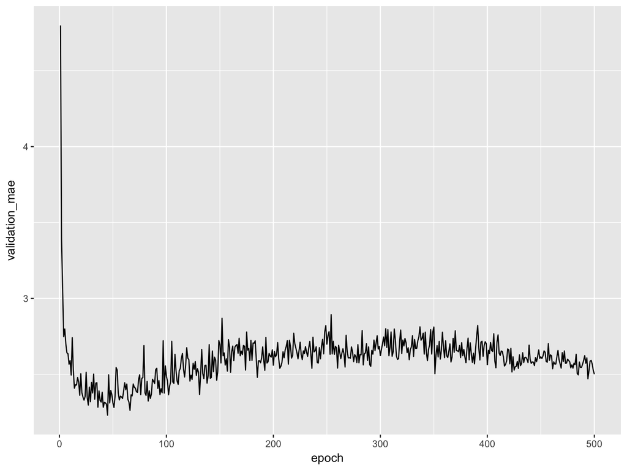

```r
library(ggplot2)
ggplot(average_mae_history, aes(x = epoch, y = validation_mae)) + geom_line()
```

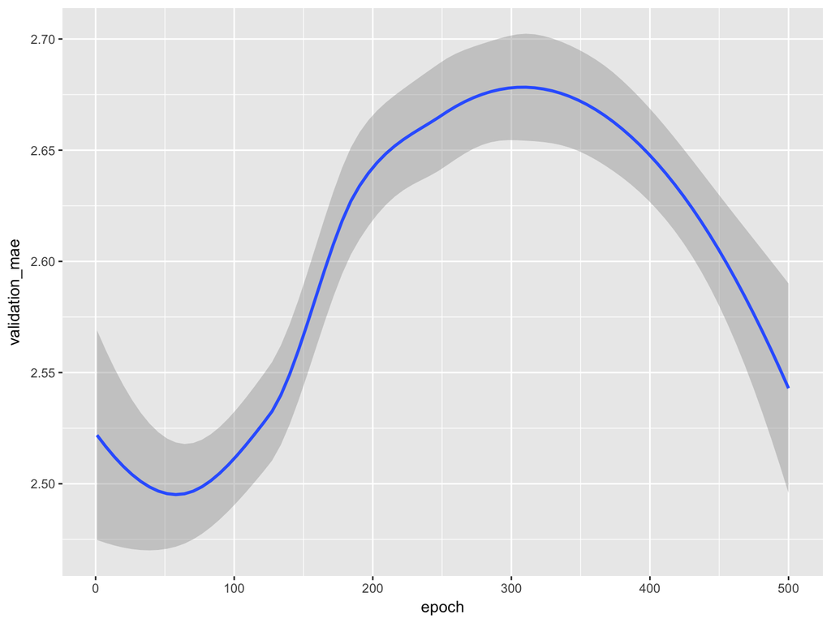

```r
ggplot(average_mae_history, aes(x = epoch, y = validation_mae)) + geom_smooth()
```

## Wrapping up

- Regression uses different loss functions from classification
- Evaluation metrics differ as well
- Rescale features with values in different ranges
- With little data, use K-fold CV
- With little data, use a small network with few hidden layers to avoid overfitting